# EP10-respuesta-equipo-5

2026-08-05

# Enunciado

**Para este ejercicio usaremos los datos de medidas anatómicas recolectados por Heinz et al. (2003) que ya conocimos en el ejercicio práctico anterior (disponibles en el archivo “EP09 Datos.csv”). Como en este case se requiere de una variable dicotómica, vamos a realizar lo siguiente:** **1- El equipo crea la variable IMC (índice de masa corporal) como el peso de una persona (en kilogramos) dividida por el cuadrado de su estatura (en metros).** **2- Si bien esta variable se usa para clasificar a las personas en varias clases de estado nutricional (bajo peso, normal, sobrepeso, obesidad, obesidad mórbida), para efectos de este ejercicio, usaremos dos clases: sobrepeso (IMC ≥ 23,2) y no sobrepeso (IMC < 23,2).** **3- El equipo crea la variable dicotómica EN (estado nutricional) de acuerdo al valor de IMC de cada persona.**

## Carga de datos e integración de nuevas variables

```r
# Cargamos el dataframe
data <- read.csv2("EP09 Datos.csv", stringsAsFactors = TRUE)

# Agregamos una nueva columna llamada IMC, siendo una variable continua
data$IMC <- data$Weight / ((data$Height / 100) ** 2)

# Ahora agregamos la variable dicotómica EN, donde sus valores son "sobrepeso" y "no sobrepeso".
data$EN <- factor(
  ifelse(data$IMC >= 23.2, "sobrepeso", "no sobrepeso"),
  levels = c("no sobrepeso", "sobrepeso")
)
```

**Ahora podemos construir un modelo de regresión logística para predecir la variable EN, de acuerdo con las siguientes instrucciones:**

# Instrucción 1

**Asegurando reproducibilidad, seleccionar una muestra de 150 mujeres (si su n° de equipo es un número par) o 150 hombres (si su n° de equipo es impar), asegurando que la mitad tenga estado nutricional “sobrepeso” y la otra mitad “no sobrepeso” en cada caso. Dividir esta muestra en dos conjuntos: los datos de 100 personas (50 con EN “sobrepeso”) para utilizar en la construcción de los modelos y 50 personas (25 con EN “sobrepeso”) para poder evaluarlos.**

Nuestro número de equipo es el 5, por lo tanto, se selecciona una muestra de 150 hombres.

```r
# Utilizamos la semilla del equipo para asegurar la reproducibilidad
set.seed(1368)

# Filtramos los datos por hombres
datos_hombres <- data %>% filter(Gender == 1)

# Dividimos los datos en dos grupos respecto a la variable EN
hombres_sobrepeso <- datos_hombres %>% filter(EN == "sobrepeso")
hombres_no_sobrepeso <- datos_hombres %>% filter(EN == "no sobrepeso")

# Nos piden seleccionar 150 hombres, por lo que procedemos a seleccionar 75 de cada grupo
muestra_sobrepeso <- hombres_sobrepeso %>% slice_sample(n = 75)
muestra_no_sobrepeso <- hombres_no_sobrepeso %>% slice_sample(n = 75)

# Unimos ambas muestras en una sola (150 personas en total, balanceada)
muestra <- rbind(muestra_sobrepeso, muestra_no_sobrepeso)

idx_train_sp <- sample(nrow(muestra_sobrepeso), 50)
casos_sobrepeso <- muestra_sobrepeso[idx_train_sp, ]
sobrepeso_no_vistos <- muestra_sobrepeso[-idx_train_sp, ]

idx_train_nsp <- sample(nrow(muestra_no_sobrepeso), 50)
casos_no_sobrepeso <- muestra_no_sobrepeso[idx_train_nsp, ]
no_sobrepeso_no_vistos <- muestra_no_sobrepeso[-idx_train_nsp, ]

casos <- rbind(casos_sobrepeso, casos_no_sobrepeso)
no_vistos <- rbind(sobrepeso_no_vistos, no_sobrepeso_no_vistos)

# Verificamos el balance de EN en ambos conjuntos
cat("Balance en el conjunto de construccion de modelos (esperado 50/50):\n")
```

```
## Balance en el conjunto de construccion de modelos (esperado 50/50):
```

```r
table(casos$EN)
```

```
##
## no sobrepeso    sobrepeso
##           50           50
```

```r
cat("\nBalance en el conjunto de datos no vistos (esperado 25/25):\n")
```

```
##
## Balance en el conjunto de datos no vistos (esperado 25/25):
```

```r
table(no_vistos$EN)
```

```
##
## no sobrepeso    sobrepeso
##           25           25
```

# Instrucción 2

**Recordar las ocho posibles variables predictoras seleccionadas de forma aleatoria en el ejercicio anterior.**

Se recuerda que las variables predictoras seleccionadas aleatoriamente en el ejercicio anterior fueron las siguientes:

```r
variables_seleccionadas <- c("Ankle.Minimum.Girth",
                             "Bitrochanteric.diameter",
                             "Age",
                             "Wrist.Minimum.Girth",
                             "Hip.Girth",
                             "Calf.Maximum.Girth",
                             "Knee.Girth",
                             "Thigh.Girth")
knitr::kable(data.frame(Variable = variables_seleccionadas),
             caption = "Variables seleccionadas aleatoriamente en el ejercicio anterior")
```

Variables seleccionadas aleatoriamente en el ejercicio anterior

| Variable |
| --- |
| Ankle.Minimum.Girth |
| Bitrochanteric.diameter |
| Age |
| Wrist.Minimum.Girth |
| Hip.Girth |
| Calf.Maximum.Girth |
| Knee.Girth |
| Thigh.Girth |

# Instrucción 3

**Seleccionar, de las otras variables, una que el equipo considere que podría ser útil para predecir la clase EN, justificando bien esta selección (idealmente con literatura).**

Como equipo vamos a seleccionar la variable **`Waist.Girth`** (circunferencia de cintura). Esta variable no es parte de las 8 seleccionadas anteriormente y tampooco es una transfomación directa del IMC.

La justificación de esta elección se apoya en tres fuentes complementarias. En primer lugar, (2010, *Nutrición Hospitalaria*) una investigación clasifican los indicadores antropométricos usados para el diagnóstico del estado nutricional en tres grupos según lo que evalúan: masa corporal total, masa muscular y masa grasa o adiposidad. La circunferencia de cintura queda ubicada dentro del grupo de indicadores de masa grasa, lo que confirma que ambas variables miden un mismo aspecto del estado nutricional. En segundo lugar,otra investigación (2002, *Am J Clin Nutr*) mostraron que el IMC y la circunferencia de cintura contribuyen de forma independiente a explicar la grasa corporal total y abdominal, por lo que la cintura entrega información complementaria al IMC. Finalmente,se desarrollaron modelos que predicen la circunferencia de cintura a partir del IMC porque, aunque están correlacionadas, ambas variables capturan aspectos distintos de la adiposidad y del riesgo metabólico asociado al exceso de peso (2012, *BMC Med Res Methodol*).

Links de las investigaciones: *Nutrición Hospitalaria* =“https://scielo.isciii.es/scielo.php?script=sci_arttext&pid=S0212-16112010000900009” *Am J Clin Nutr* = “https://pubmed.ncbi.nlm.nih.gov/11916754/” *BMC Med Res Methodol* =“https://pubmed.ncbi.nlm.nih.gov/22862851/”

# Instrucción 4

**Usando el entorno R, construir un modelo de regresión logística con el predictor seleccionado en el paso anterior y utilizando de la muestra obtenida.**

Como ahora vamos a trabajar con un modelo de regresión logística, utilizamos la función glm().

```r
modelo_rlogis <- glm(EN ~ Waist.Girth, data = casos, family = binomial(link = "logit"))
summary(modelo_rlogis)
```

```
##
## Call:
## glm(formula = EN ~ Waist.Girth, family = binomial(link = "logit"),
##     data = casos)
##
## Coefficients:
##              Estimate Std. Error z value Pr(>|z|)
## (Intercept) -18.64954    3.94727  -4.725 2.30e-06 ***
## Waist.Girth   0.22770    0.04832   4.712 2.45e-06 ***
## ---
## Signif. codes:  0 '***' 0.001 '**' 0.01 '*' 0.05 '.' 0.1 ' ' 1
##
## (Dispersion parameter for binomial family taken to be 1)
##
##     Null deviance: 138.629  on 99  degrees of freedom
## Residual deviance:  99.898  on 98  degrees of freedom
## AIC: 103.9
##
## Number of Fisher Scoring iterations: 5
```

# Instrucción 5

**Usando herramientas estándares para la exploración de modelos del entorno R, buscar entre dos y cinco predictores de entre las variables seleccionadas al azar, recordadas en el punto 2, para agregar al modelo obtenido en el paso 4.**

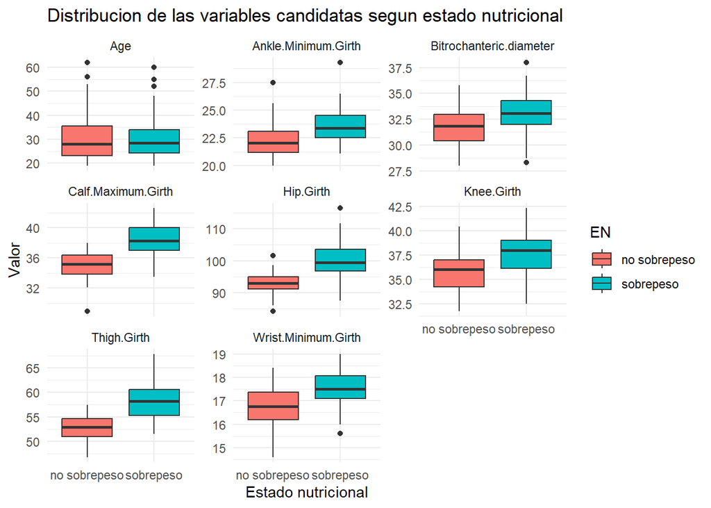

```r
# Exploracion grafica de las 8 variables candidatas segun EN
datos_exploracion <- casos %>%
  dplyr::select(EN, all_of(variables_seleccionadas)) %>%
  pivot_longer(-EN, names_to = "variable", values_to = "valor")

ggplot(datos_exploracion, aes(x = EN, y = valor, fill = EN)) +
  geom_boxplot() +
  facet_wrap(~ variable, scales = "free_y") +
  theme_minimal() +
  labs(title = "Distribucion de las variables candidatas segun estado nutricional",
       x = "Estado nutricional", y = "Valor")
```

```r
# Matriz de correlacion entre las variables candidatas
round(cor(casos[, variables_seleccionadas]), 2)
```

```
##                         Ankle.Minimum.Girth Bitrochanteric.diameter   Age
## Ankle.Minimum.Girth                    1.00                    0.44  0.05
## Bitrochanteric.diameter                0.44                    1.00  0.21
## Age                                    0.05                    0.21  1.00
## Wrist.Minimum.Girth                    0.62                    0.39  0.10
## Hip.Girth                              0.48                    0.72  0.16
## Calf.Maximum.Girth                     0.55                    0.53  0.01
## Knee.Girth                             0.64                    0.62  0.04
## Thigh.Girth                            0.42                    0.46 -0.09
##                         Wrist.Minimum.Girth Hip.Girth Calf.Maximum.Girth
## Ankle.Minimum.Girth                    0.62      0.48               0.55
## Bitrochanteric.diameter                0.39      0.72               0.53
## Age                                    0.10      0.16               0.01
## Wrist.Minimum.Girth                    1.00      0.44               0.42
## Hip.Girth                              0.44      1.00               0.66
## Calf.Maximum.Girth                     0.42      0.66               1.00
## Knee.Girth                             0.46      0.73               0.70
## Thigh.Girth                            0.34      0.77               0.72
##                         Knee.Girth Thigh.Girth
## Ankle.Minimum.Girth           0.64        0.42
## Bitrochanteric.diameter       0.62        0.46
## Age                           0.04       -0.09
## Wrist.Minimum.Girth           0.46        0.34
## Hip.Girth                     0.73        0.77
## Calf.Maximum.Girth            0.70        0.72
## Knee.Girth                    1.00        0.64
## Thigh.Girth                   0.64        1.00
```

Luego, para la selección de predictores se utiliza búsqueda escalonada hacia adelante (forward stepwise), con la función `step()`, partiendo de `modelo_rlogis` (el modelo de RLog) y evaluando incorporar, de a una, las variables del modelo `modelo_rlogitm`. El criterio usado es el AIC (a menor AIC, mejor el modelo, comparando los modelos entre sí sobre los mismos datos y variable de respuesta). Como el enunciado exige agregar **entre 2 y 5 predictores**, se limita explícitamente la búsqueda a un máximo de 5 pasos con el argumento `steps = 5`, en vez de dejar que `step()` siga agregando variables mientras el AIC siga bajando (lo que podría entregar un modelo con más de 5 predictores agregados e incumplir la restricción del enunciado):

```r
# Busqueda escalonada (stepwise) basada en (funcion step()) para explorar cuales de las 8 variables mejoran el modelo simple.
formula_scope_inferior <- ~ Waist.Girth
formula_scope_superior <- as.formula(
  paste("~ Waist.Girth +", paste(variables_seleccionadas, collapse = " + "))
)

modelo_rlogitm <- step(
  modelo_rlogis,
  scope = list(lower = formula_scope_inferior, upper = formula_scope_superior),
  direction = "forward",
  steps = 5,
  trace = 1
)
```

```
## Start:  AIC=103.9
## EN ~ Waist.Girth
##
##                           Df Deviance     AIC
## + Thigh.Girth              1   76.377  82.377
## + Calf.Maximum.Girth       1   77.566  83.566
## + Age                      1   87.976  93.976
## + Hip.Girth                1   92.429  98.429
## + Wrist.Minimum.Girth      1   93.982  99.982
## <none>                         99.898 103.898
## + Knee.Girth               1   98.873 104.873
## + Ankle.Minimum.Girth      1   99.061 105.061
## + Bitrochanteric.diameter  1   99.543 105.543
##
## Step:  AIC=82.38
## EN ~ Waist.Girth + Thigh.Girth
##
##                           Df Deviance    AIC
## + Calf.Maximum.Girth       1   69.158 77.158
## + Wrist.Minimum.Girth      1   73.617 81.617
## <none>                         76.377 82.377
## + Bitrochanteric.diameter  1   74.510 82.510
## + Knee.Girth               1   74.660 82.660
## + Age                      1   75.409 83.409
## + Hip.Girth                1   76.223 84.223
## + Ankle.Minimum.Girth      1   76.371 84.371
##
## Step:  AIC=77.16
## EN ~ Waist.Girth + Thigh.Girth + Calf.Maximum.Girth
##
##                           Df Deviance    AIC
## + Knee.Girth               1   62.677 72.677
## + Wrist.Minimum.Girth      1   65.421 75.421
## + Bitrochanteric.diameter  1   65.627 75.627
## <none>                         69.158 77.158
## + Age                      1   68.528 78.528
## + Ankle.Minimum.Girth      1   68.580 78.580
## + Hip.Girth                1   69.034 79.034
##
## Step:  AIC=72.68
```

[output cut: 9 more lines]

```
##
## Step:  AIC=66.99
## EN ~ Waist.Girth + Thigh.Girth + Calf.Maximum.Girth + Knee.Girth +
##     Wrist.Minimum.Girth
##
##                           Df Deviance    AIC
## + Age                      1   51.945 65.945
## <none>                         54.987 66.987
## + Bitrochanteric.diameter  1   53.309 67.309
## + Ankle.Minimum.Girth      1   53.934 67.934
## + Hip.Girth                1   54.815 68.815
##
## Step:  AIC=65.94
## EN ~ Waist.Girth + Thigh.Girth + Calf.Maximum.Girth + Knee.Girth +
##     Wrist.Minimum.Girth + Age
```

```r
summary(modelo_rlogitm)
```

```
##
## Call:
## glm(formula = EN ~ Waist.Girth + Thigh.Girth + Calf.Maximum.Girth +
##     Knee.Girth + Wrist.Minimum.Girth + Age, family = binomial(link = "logit"),
##     data = casos)
##
## Coefficients:
##                      Estimate Std. Error z value Pr(>|z|)
## (Intercept)         -66.88235   17.86000  -3.745 0.000181 ***
## Waist.Girth           0.23251    0.11553   2.013 0.044152 *
## Thigh.Girth           0.34453    0.18111   1.902 0.057125 .
## Calf.Maximum.Girth    1.18336    0.37499   3.156 0.001601 **
## Knee.Girth           -0.99882    0.33637  -2.969 0.002984 **
## Wrist.Minimum.Girth   1.48310    0.56021   2.647 0.008111 **
## Age                  -0.10689    0.06752  -1.583 0.113387
## ---
## Signif. codes:  0 '***' 0.001 '**' 0.01 '*' 0.05 '.' 0.1 ' ' 1
##
## (Dispersion parameter for binomial family taken to be 1)
##
##     Null deviance: 138.629  on 99  degrees of freedom
## Residual deviance:  51.945  on 93  degrees of freedom
## AIC: 65.945
##
## Number of Fisher Scoring iterations: 7
```

```r
predictores_rlogitm <- setdiff(names(coef(modelo_rlogitm)), c("(Intercept)", "Waist.Girth"))
cat(sprintf("Predictores agregados al modelo simple (%d en total): %s\n",
            length(predictores_rlogitm), paste(predictores_rlogitm, collapse = ", ")))
```

```
## Predictores agregados al modelo simple (5 en total): Thigh.Girth, Calf.Maximum.Girth, Knee.Girth, Wrist.Minimum.Girth, Age
```

La búsqueda agrega, en orden, `Thigh.Girth`, `Calf.Maximum.Girth`, `Knee.Girth`, `Wrist.Minimum.Girth` y `Age` (5 predictores agregados al modelo de RLS, tal como exige el enunciado), bajando el AIC de 103.9 a 65.94. Por lo tanto el modelo final de RLog queda con 6 predictores en total.

El modelo de RLog presenta una notable caída en la desviación de 138,629 a 51,945, por lo que estos predictores son útiles para el modelo y epxlican adecuadamente los datos de este.

# Instrucción 6

**Evaluar la confiabilidad y generalidad de los modelos (i.e. que tengan un buen nivel de ajuste, que cumplen las condiciones para RLogit y no están dominados por casos sobreinfluyentes) y “arreglarlos” en caso de que tengan algún problema.**

#### Confiabilidad: significancia global y bondad de ajuste

```r
en_num_casos <- ifelse(casos$EN == "sobrepeso", 1, 0)

cat("RLogiS \n")
```

```
## RLogiS
```

```r
anova(update(modelo_rlogis, . ~ 1), modelo_rlogis, test = "Chisq")
```

```
## Analysis of Deviance Table
##
## Model 1: EN ~ 1
## Model 2: EN ~ Waist.Girth
##   Resid. Df Resid. Dev Df Deviance  Pr(>Chi)
## 1        99    138.629
## 2        98     99.898  1   38.731 4.863e-10 ***
## ---
## Signif. codes:  0 '***' 0.001 '**' 0.01 '*' 0.05 '.' 0.1 ' ' 1
```

```r
cat("RLogitM \n")
```

```
## RLogitM
```

```r
anova(update(modelo_rlogitm, . ~ 1), modelo_rlogitm, test = "Chisq")
```

```
## Analysis of Deviance Table
##
## Model 1: EN ~ 1
## Model 2: EN ~ Waist.Girth + Thigh.Girth + Calf.Maximum.Girth + Knee.Girth +
##     Wrist.Minimum.Girth + Age
##   Resid. Df Resid. Dev Df Deviance  Pr(>Chi)
## 1        99    138.629
## 2        93     51.945  6   86.685 < 2.2e-16 ***
## ---
## Signif. codes:  0 '***' 0.001 '**' 0.01 '*' 0.05 '.' 0.1 ' ' 1
```

```r
# Prueba de bondad de ajuste de Hosmer-Lemeshow
hl_rlogis <- generalhoslem::logitgof(en_num_casos, fitted(modelo_rlogis), g = 10)
hl_rlogis
```

```
##
##  Hosmer and Lemeshow test (binary model)
##
## data:  en_num_casos, fitted(modelo_rlogis)
## X-squared = 5.6408, df = 8, p-value = 0.6874
```

```r
hl_rlogitm <- generalhoslem::logitgof(en_num_casos, fitted(modelo_rlogitm), g = 10)
```

```
## Warning in generalhoslem::logitgof(en_num_casos, fitted(modelo_rlogitm), : At
## least one cell in the expected frequencies table is < 1. Chi-square
## approximation may be incorrect.
```

```r
hl_rlogitm
```

```
##
##  Hosmer and Lemeshow test (binary model)
##
## data:  en_num_casos, fitted(modelo_rlogitm)
## X-squared = 1.7064, df = 8, p-value = 0.9887
```

Dado los resultados ambos modelos son significativamente mejores que el modelo nulo. RLogiS y RLogitM no tienen evidencia de mal ajuste, pero hay una advertencia de “expected frequencies < 1” que no invalida la conclusión dado lo alto de los p-valores pero podria ser una limitación por tener pocos datos por decil de riesgo.

#### Confiabilidad: multicolinealidad y linealidad del logit

```r
# Factor de inflacion de la varianza (VIF)
car::vif(modelo_rlogitm)
```

```
##         Waist.Girth         Thigh.Girth  Calf.Maximum.Girth          Knee.Girth
##            4.225139            1.844328            1.906082            3.635727
## Wrist.Minimum.Girth                 Age
##            1.489080            3.083174
```

Todos los VIF de RLogitM están entre 1.49 y 4.23 y el umbral típico de preocupación es VIF > 5 o VIF > 10, por lo que no hay problema de multicolinealidad relevante.

```r
# Prueba de Box-Tidwell para la linealidad del logit en los predictores continuos del modelo final
predictores_finales <- setdiff(names(coef(modelo_rlogitm)), "(Intercept)")
formula_boxtidwell <- as.formula(paste("en_num_casos ~", paste(predictores_finales, collapse = " + ")))
car::boxTidwell(formula_boxtidwell, data = casos)
```

```
##                     MLE of lambda Score Statistic (t) Pr(>|t|)
## Waist.Girth              -0.37115             -0.4187   0.6765
## Thigh.Girth              -1.39273             -0.5400   0.5906
## Calf.Maximum.Girth        1.99219              0.2204   0.8261
## Knee.Girth               -1.64291              0.5061   0.6141
## Wrist.Minimum.Girth       0.21725              0.0536   0.9574
## Age                      -0.40866              0.5577   0.5785
##
## iterations =  26
##
## Score test for null hypothesis that all lambdas = 1:
## F = 0.15987, df = 6 and 87, Pr(>F) = 0.9865
```

Los p-valores individuales van de 0.58 a 0.96, y el test conjunto da F=0.16, gl=(6,87), p=0.987. No se rechaza H0. por lo que no hay evidencia de que se viole el supuesto de linealidad del logit.

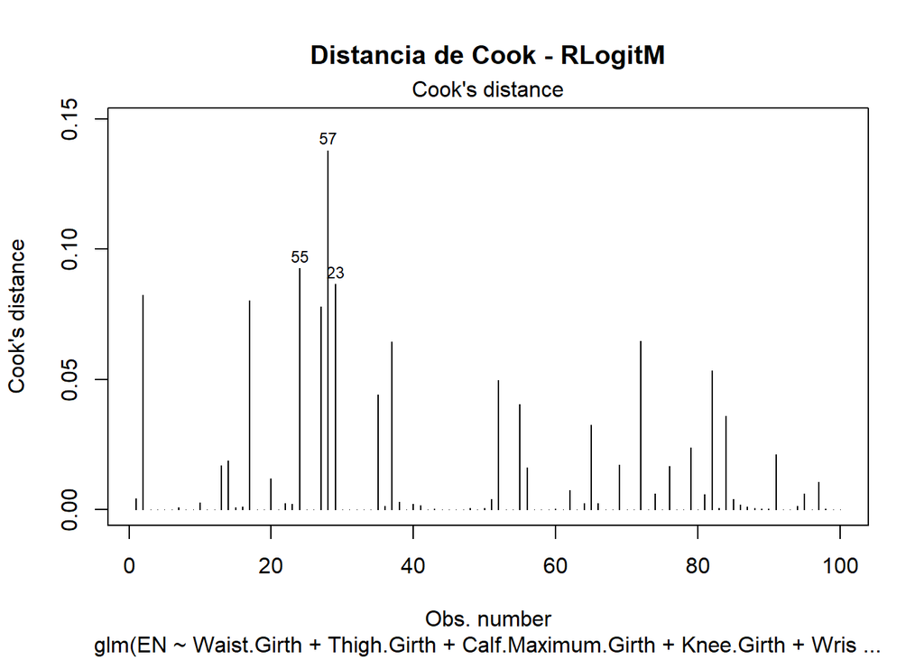

```r
# Distancia de Cook
plot(modelo_rlogitm, which = 4, main = "Distancia de Cook - RLogitM")
```

```r
cooksd <- cooks.distance(modelo_rlogitm)
umbral_cook <- 4 / nrow(casos)
casos_influyentes <- which(cooksd > umbral_cook)
cat(sprintf("Casos con Distancia de Cook > %.3f: %d de %d observaciones (%.1f%%)\n",
            umbral_cook, length(casos_influyentes), nrow(casos),
            100 * length(casos_influyentes) / nrow(casos)))
```

```
## Casos con Distancia de Cook > 0.040: 12 de 100 observaciones (12.0%)
```

```r
residuos_estandarizados <- rstandard(modelo_rlogitm)
cat(sprintf("Casos con residuos estandarizados fuera de [-3, 3]: %d\n",
            sum(abs(residuos_estandarizados) > 3)))
```

```
## Casos con residuos estandarizados fuera de [-3, 3]: 1
```

```r
# Razon de casos por predictor
n_casos_minoritarios <- min(table(casos$EN))
n_predictores_rlogitm <- length(coef(modelo_rlogitm)) - 1
razon_epv <- n_casos_minoritarios / n_predictores_rlogitm
cat(sprintf("Razon de casos por predictor (EPV) para RLogitM: %.1f\n", razon_epv))
```

```
## Razon de casos por predictor (EPV) para RLogitM: 8.3
```

La regla práctica, EPV ≥ 10 para que las estimaciones de un modelo logístico sean estables. Los resultados dieron 8.3, entonces RLogitM queda levemente por debajo del mínimo recomendado,por lo que los coeficientes e intervalos de confianza podrían ser algo menos estables de lo ideal, y hay cierto riesgo de sobreajuste al haber agregado 6 predictores con solo 50 casos por clase.

```r
# Corrección del modelo: se elimina Age por ser el predictor menos significativo

modelo_rlogitm_corregido <- update(modelo_rlogitm, . ~ . - Age)

summary(modelo_rlogitm_corregido)
```

```
##
## Call:
## glm(formula = EN ~ Waist.Girth + Thigh.Girth + Calf.Maximum.Girth +
##     Knee.Girth + Wrist.Minimum.Girth, family = binomial(link = "logit"),
##     data = casos)
##
## Coefficients:
##                      Estimate Std. Error z value Pr(>|z|)
## (Intercept)         -69.73868   17.87458  -3.902 9.56e-05 ***
## Waist.Girth           0.09692    0.06606   1.467  0.14233
## Thigh.Girth           0.47855    0.16258   2.944  0.00324 **
## Calf.Maximum.Girth    1.11305    0.35695   3.118  0.00182 **
## Knee.Girth           -0.78157    0.27920  -2.799  0.00512 **
## Wrist.Minimum.Girth   1.35940    0.53094   2.560  0.01046 *
## ---
## Signif. codes:  0 '***' 0.001 '**' 0.01 '*' 0.05 '.' 0.1 ' ' 1
##
## (Dispersion parameter for binomial family taken to be 1)
##
##     Null deviance: 138.629  on 99  degrees of freedom
## Residual deviance:  54.987  on 94  degrees of freedom
## AIC: 66.987
##
## Number of Fisher Scoring iterations: 7
```

```r
# Nuevo EPV
n_predictores_corregido <- length(coef(modelo_rlogitm_corregido)) - 1
epv_corregido <- min(table(casos$EN)) / n_predictores_corregido

cat(sprintf("Nuevo EPV: %.1f\n", epv_corregido))
```

```
## Nuevo EPV: 10.0
```

```r
# Verificar nuevamente VIF
car::vif(modelo_rlogitm_corregido)
```

```
##         Waist.Girth         Thigh.Girth  Calf.Maximum.Girth          Knee.Girth
##            1.514835            1.502712            1.764406            2.434018
## Wrist.Minimum.Girth
##            1.431823
```

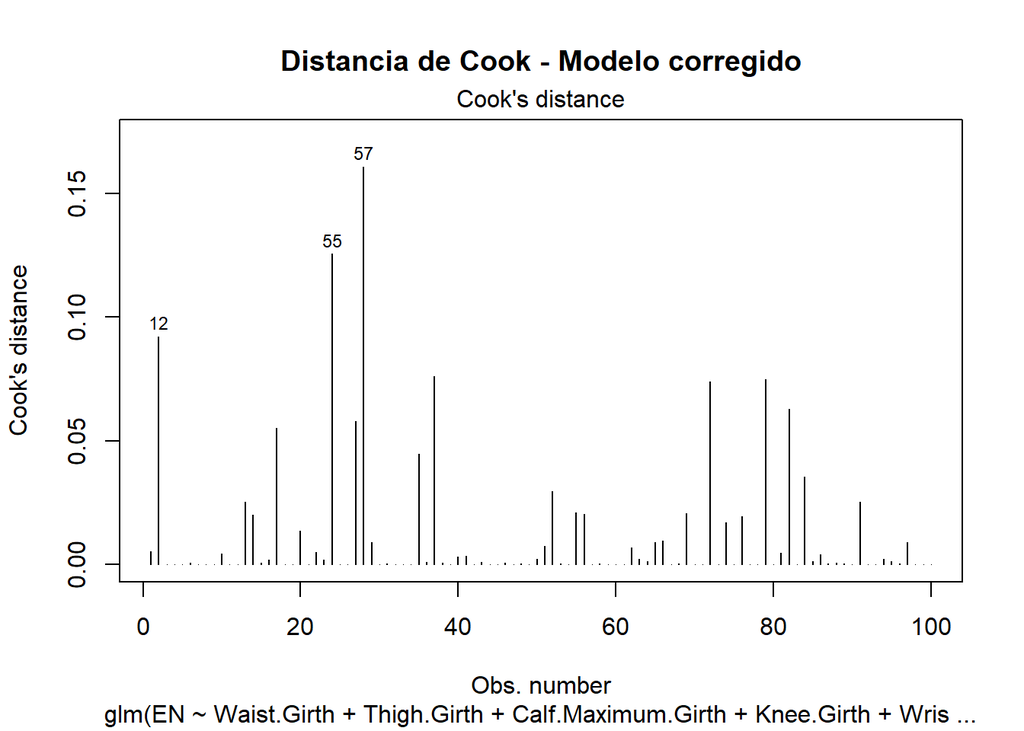

```r
# Distancia de Cook
plot(modelo_rlogitm_corregido,
     which = 4,
     main = "Distancia de Cook - Modelo corregido")
```

```r
cooksd_corregido <- cooks.distance(modelo_rlogitm_corregido)

umbral_cook <- 4 / nrow(casos)

casos_influyentes_corregido <- which(cooksd_corregido > umbral_cook)

cat(sprintf("Casos influyentes luego de la corrección: %d\n",
            length(casos_influyentes_corregido)))
```

```
## Casos influyentes luego de la corrección: 10
```

Debido a que el EPV fue inferior al valor recomendado de 10, se optó por simplificar el modelo eliminando el predictor Age, ya que fue la variable menos significativa (p = 0.113). Con ello el modelo quedó compuesto por cinco predictores, aumentando el EPV desde 8.3 hasta 10.0, cumpliendo la recomendación habitual para regresión logística y disminuyendo el riesgo de sobreajuste. Además, la eliminación de esta variable redujo los valores de VIF y el número de casos influyentes según la distancia de Cook, pasando de 12 a 10 observaciones, sin deteriorar de forma importante el ajuste del modelo.

# Instrucción 7

**Usando código estándar, evaluar el poder predictivo de los modelos con los datos de las 50 personas que no se incluyeron en su construcción en términos de sensibilidad y especificidad.**

```r
# Evaluación del poder predictivo utilizando los datos no vistos

probabilidades <- predict(modelo_rlogitm_corregido,
                          newdata = no_vistos,
                          type = "response")

predicciones <- ifelse(probabilidades >= 0.5,
                       "sobrepeso",
                       "no sobrepeso")

predicciones <- factor(predicciones,
                       levels = levels(no_vistos$EN))

# Matriz de confusión
matriz_confusion <- table(
  Real = no_vistos$EN,
  Predicho = predicciones
)

matriz_confusion
```

```
##               Predicho
## Real           no sobrepeso sobrepeso
##   no sobrepeso           21         4
##   sobrepeso               8        17
```

```r
# Cálculo de sensibilidad, especificidad y exactitud

VP <- matriz_confusion["sobrepeso", "sobrepeso"]
VN <- matriz_confusion["no sobrepeso", "no sobrepeso"]
FP <- matriz_confusion["no sobrepeso", "sobrepeso"]
FN <- matriz_confusion["sobrepeso", "no sobrepeso"]

sensibilidad <- VP / (VP + FN)
especificidad <- VN / (VN + FP)
exactitud <- (VP + VN) / sum(matriz_confusion)

cat(sprintf("Sensibilidad: %.3f\n", sensibilidad))
```

```
## Sensibilidad: 0.680
```

```r
cat(sprintf("Especificidad: %.3f\n", especificidad))
```

```
## Especificidad: 0.840
```

```r
cat(sprintf("Exactitud: %.3f\n", exactitud))
```

```
## Exactitud: 0.760
```

Finalmente, el modelo corregido fue evaluado utilizando el conjunto de datos reservado para validación, compuesto por 50 observaciones que no participaron en la construcción del modelo. A partir de la matriz de confusión se calcularon la sensibilidad y la especificidad, métricas que permiten evaluar la capacidad del modelo para identificar correctamente a las personas con y sin sobrepeso. El modelo obtuvo una sensibilidad de 0.68, una especificidad de 0.84 y una exactitud global de 0.76, lo que indica un buen desempeño predictivo, especialmente para identificar correctamente a las personas sin sobrepeso. En conjunto, estos resultados muestran que el modelo presenta una capacidad de generalización adecuada sobre datos no utilizados durante su construcción.